# Dataset evaluation

```r
library(dplyr, warn.conflicts = FALSE)
library(formattable)
library(kableExtra)
library(tidyverse)
library(cluster)
library(factoextra)
library(gridExtra)
library(tidytext)
library(wordcloud)
library(wordcloud2)
library(reshape)
library(ggdendro)
library(tm)
library(lexiconPT)

colors <- c("#E69F00", "#56B4E9", "#009E73", "#CC79A7", "#D55E00")
```

```r
#musicas <- read.csv2("../dataset/musicas_de_forro_com_letras_e_datas.csv")

musicas <- read.csv("../dataset/musicas_de_forro_com_letras_e_datas.csv", sep = ";")
```

```r
musicas$ano <- musicas$ano %>% as.character %>% as.numeric

#summary(musicas)
```

# Para organizar os dados

```r
# Classifica por década
musicas <- musicas %>%
  mutate(decada =
           ifelse(musicas$ano %in% 1950:1959, "1950s" ,
           ifelse(musicas$ano %in% 1960:1969, "1960s",
           ifelse(musicas$ano %in% 1970:1979, "1970s",
           ifelse(musicas$ano %in% 1980:1989, "1980s",
           ifelse(musicas$ano %in% 1990:1999, "1990s",
           ifelse(musicas$ano %in% 2000:2009, "2000s",
           ifelse(musicas$ano %in% 2010:2019, "2010s",
                  "NA"))))))))

musicas$letra <- musicas$letra %>% str_replace_all("[\r\n]", " ")

palavras_indesejadas = c("repeat", "repete", "ltda", "lyrics", "instrumental", "repete", "edições", "musical", "musicais", "site", "oficial", "fonte", "intro", "refrão", "crédito", "enviado", "editora", "contribuição", "leandrostz", "mariano", "richards", "halen", "bernie", "taupin", "2x", "(2x)")

head(stopwords('pt'), 15)
```

```
 [1] "de"   "a"    "o"    "que"  "e"    "do"   "da"   "em"   "um"   "para" "com"  "não"  "uma"  "os"   "no"
```

```r
stopwords_pt <- data.frame(word = tm::stopwords("portuguese"))


FiltraDadosPorDecada <- function(d) {
  ds_filtered <- musicas %>%filter(decada == d)

  result <- ds_filtered %>%
  unnest_tokens(word, letra) %>%
  anti_join(stopwords_pt) %>%
  distinct() %>%
  filter(!word %in% palavras_indesejadas) %>%
  filter(nchar(word) > 3)
  return(result)
}
```

```r
theme_lyrics <- function()
{
  theme(plot.title = element_text(hjust = 0.5),
        axis.text.x = element_blank(),
        axis.ticks = element_blank(),
        panel.grid.major = element_blank(),
        panel.grid.minor = element_blank(),
        legend.position = "none")
}
```

Para termos noção da quantidade de letras que temos. É óbvil e notável que temos mais músicas a partir dos anos 2000.

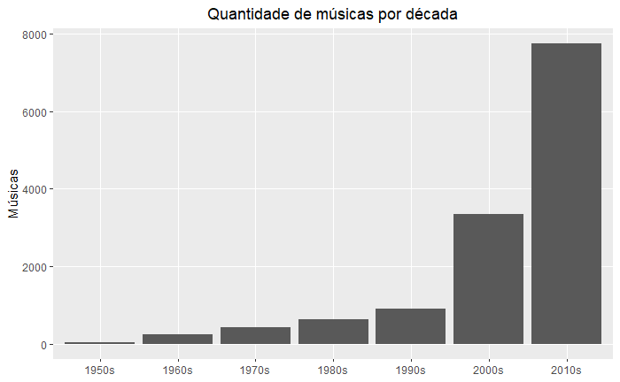

```r
musicas %>%
  filter(decada != "NA") %>%
  group_by(decada) %>%
  summarise(numero_de_musicas = n()) %>%
  ggplot() +
  geom_bar(aes(x = decada, y = numero_de_musicas), stat = "identity")  +
  theme(plot.title = element_text(hjust = 0.5), legend.title = element_blank(), panel.grid.minor = element_blank()) +
  ggtitle("Quantidade de músicas por década") +
  labs(x = NULL, y = "Músicas")
```

Para visualizarmos a quantidade de palavras mais utilizadas por década.

```r
musicas_filtradas <- musicas %>%
  unnest_tokens(word, letra) %>%
  anti_join(stopwords_pt) %>%
  distinct() %>%
  filter(!word %in% palavras_indesejadas) %>%
  filter(nchar(word) > 3)
```

```
Column `word` joining character vector and factor, coercing into character vector
```

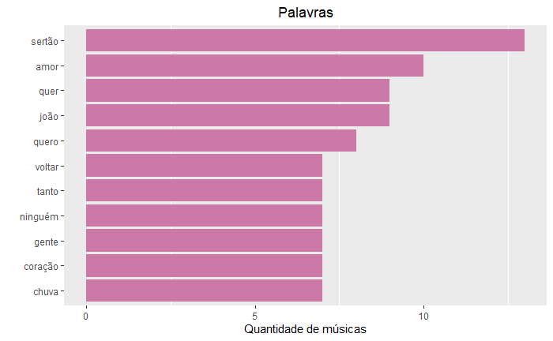

```r
wordsCounterPerDecade <- function(d) {
  ds <- musicas_filtradas %>% filter(decada == d)

  ds %>%
  count(word, sort = TRUE) %>%
  top_n(10) %>%
  ungroup() %>%
  mutate(word = reorder(word, n)) %>%
  ggplot() +
    geom_col(aes(word, n), fill = colors[4]) +
    theme(legend.position = "none",
          plot.title = element_text(hjust = 0.5),
          panel.grid.major = element_blank()) +
    xlab("") +
    ylab("Quantidade de músicas") +
    ggtitle("Palavras") +
    coord_flip()
}

wordsCounterPerDecade("1950s")
```

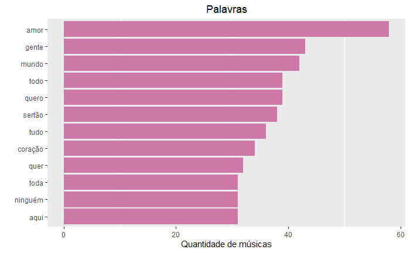

```r
wordsCounterPerDecade("1960s")
```

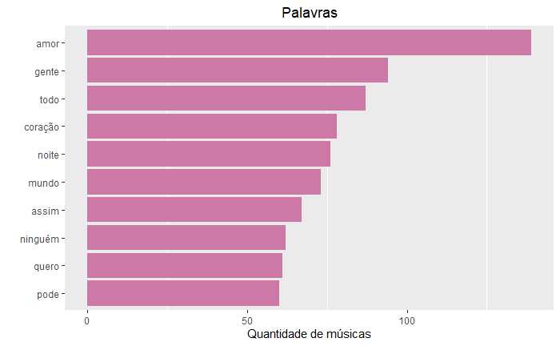

```r
wordsCounterPerDecade("1970s")
```

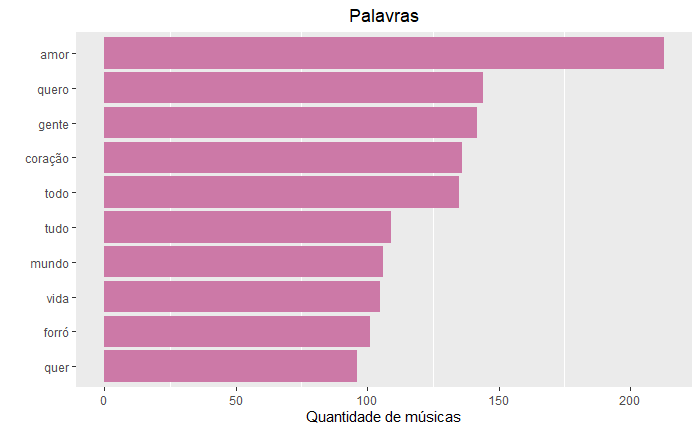

```r
wordsCounterPerDecade("1980s")
```

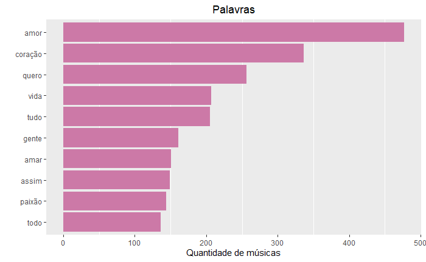

```r
wordsCounterPerDecade("1990s")
```

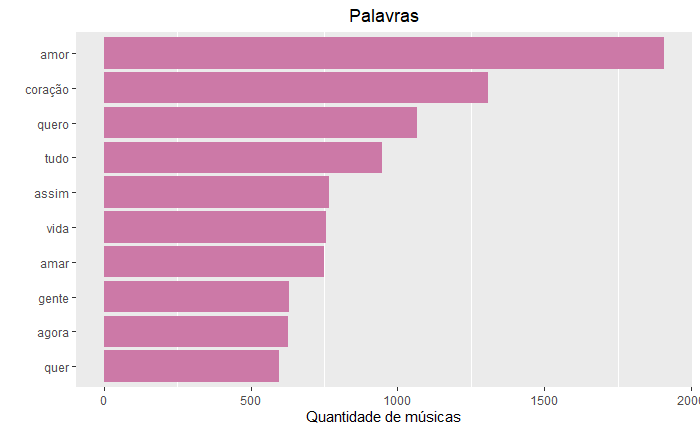

```r
wordsCounterPerDecade("2000s")
```

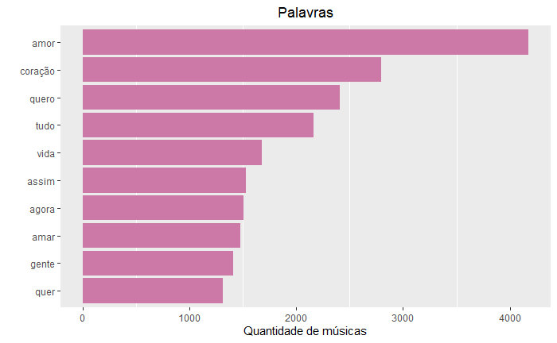

```r
wordsCounterPerDecade("2010s")
```

```r
quantidade_palavras <- musicas_filtradas %>%
  count(word, sort = TRUE)

ContaPalavras<- function(ds_filtered) {
  result <- ds_filtered %>% count(word, sort = TRUE)
  return(result)
}

filtraMusicasPorDecada <- function(d) {
  ds_filtered <- musicas %>% filter(decada == d)

  result <- ds_filtered %>%
  unnest_tokens(word, letra) %>%
  anti_join(stopwords_pt) %>%
  distinct() %>%
  filter(!word %in% palavras_indesejadas) %>%
  filter(nchar(word) > 3)
  return(result)
}
```

```r
wordcloud2((filtraMusicasPorDecada("1950s") %>%  ContaPalavras)[1:200, ], size = .5, title(main = "title"))
```

[output not shown]

```
`show.legend` must be a logical vector.
```

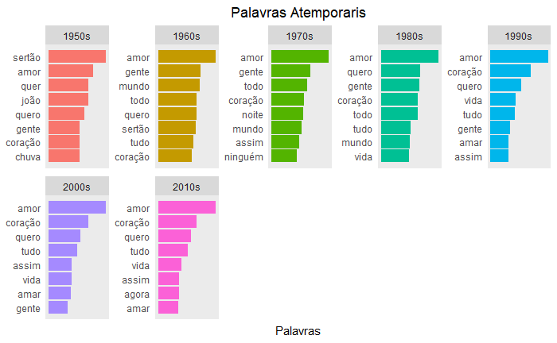

```r
timeless_words <- musicas_filtradas %>%
  filter(decada != 'NA') %>%
  group_by(decada) %>%
  count(word, decada, sort = TRUE) %>%
  slice(seq_len(8)) %>%
  ungroup() %>%
  arrange(decada,n) %>%
  mutate(row = row_number())

timeless_words %>%
  ggplot(aes(row, n, fill = decada)) +
    geom_col(show.legend = NULL) +
    labs(x = NULL, y = "Palavras") +
    ggtitle("Palavras Atemporaris") +
    theme_lyrics() +
    facet_wrap(~decada, scales = "free", ncol = 5) +
    scale_x_continuous(breaks = timeless_words$row, labels = timeless_words$word) +
    coord_flip()
```

#Palavras mais longas Palavras maiores podem acrescentar complexidade nas letras e também podem indicar, ao longo do tempo, se as letras ficaram mais ou menos complexas a partir desse ponto

Pode indicar, então, simplicidade ou não?

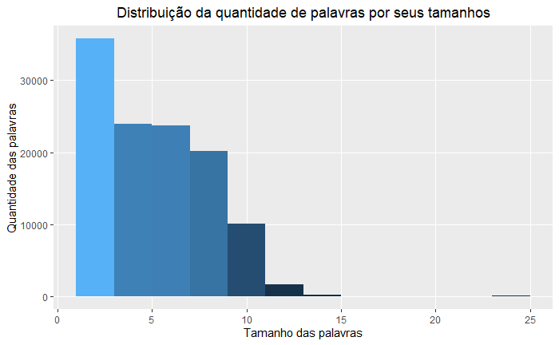

```r
ContaTamangoDasPalavrasPorDecada <- function(d) {
  ds <- musicas %>% filter(decada == d)
  result <- ds %>%
  unnest_tokens(word, letra) %>%
  group_by(nome, decada) %>%
  distinct() %>%
  filter(!word %in% palavras_indesejadas) %>%
  mutate(word_length = nchar(word))
  return(result)
}

PlotaTamanhosDasPalavras <- function(word_lengths, decada) {
  word_lengths %>%
  count(word_length, sort = TRUE) %>%
  ggplot(aes(word_length), binwidth = 10) +
  geom_histogram(aes(fill = ..count..), breaks = seq(1,25, by = 2),
  show.legend = FALSE) +
  xlab("Tamanho das palavras") + ylab("Quantidade das palavras") +
  ggtitle(paste("Distribuição do tamanho das palavras a década de ")) +
  theme(plot.title = element_text(hjust = 0.5), panel.grid.minor = element_blank())
}

all_word_lengths <- musicas %>%
  unnest_tokens(word, letra) %>%
  group_by(nome, decada) %>%
  distinct() %>%
  filter(!word %in% palavras_indesejadas) %>%
  mutate(word_length = nchar(word))

all_word_lengths %>%
  count(word_length, sort = TRUE) %>%
  ggplot(aes(word_length), binwidth = 10) +
  geom_histogram(aes(fill = ..count..), breaks = seq(1,25, by = 2),
  show.legend = FALSE) +
  xlab("Tamanho das palavras") + ylab("Quantidade das palavras") +
  ggtitle("Distribuição da quantidade de palavras por seus tamanhos") +
  theme(plot.title = element_text(hjust = 0.5), panel.grid.minor = element_blank())
```

E por década?

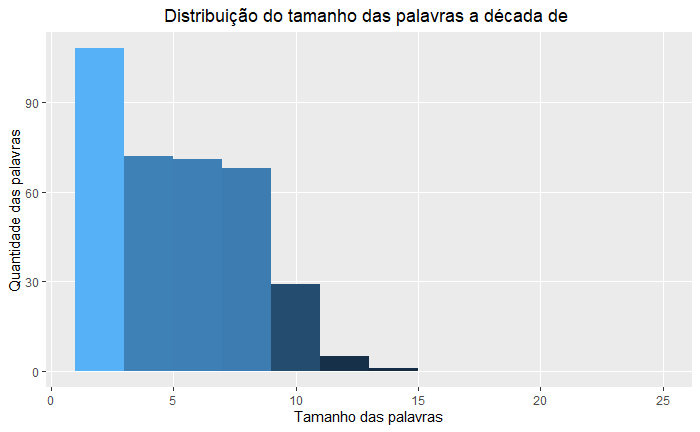

```r
PlotaTamanhosDasPalavras(ContaTamangoDasPalavrasPorDecada("1950s"), "1950s")
```

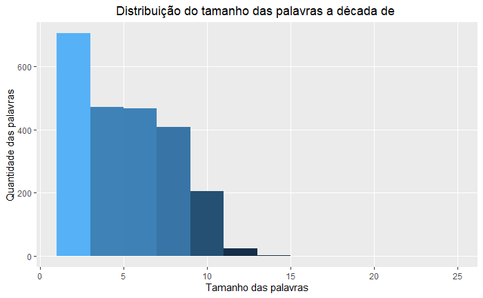

```r
PlotaTamanhosDasPalavras(ContaTamangoDasPalavrasPorDecada("1960s"), "1960s")
```

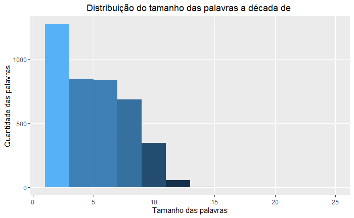

```r
PlotaTamanhosDasPalavras(ContaTamangoDasPalavrasPorDecada("1970s"), "1970s")
```

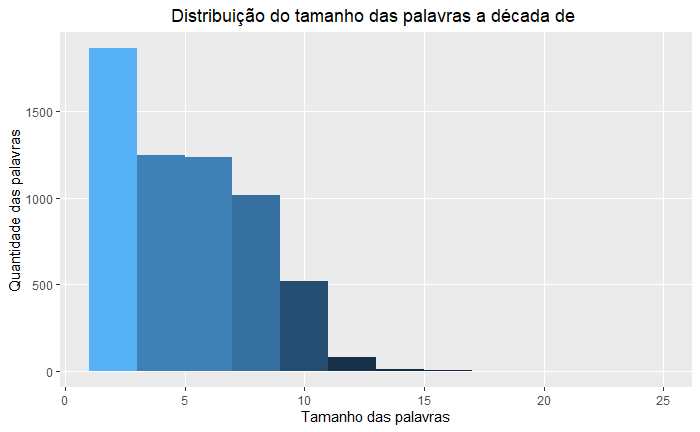

```r
PlotaTamanhosDasPalavras(ContaTamangoDasPalavrasPorDecada("1980s"), "1980s")
```

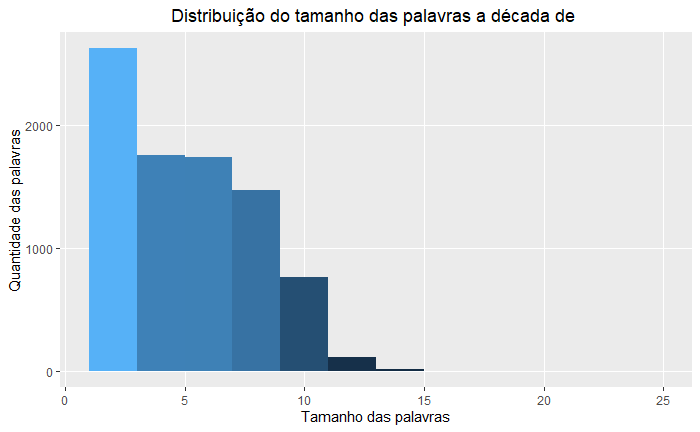

```r
PlotaTamanhosDasPalavras(ContaTamangoDasPalavrasPorDecada("1990s"), "1990s")
```

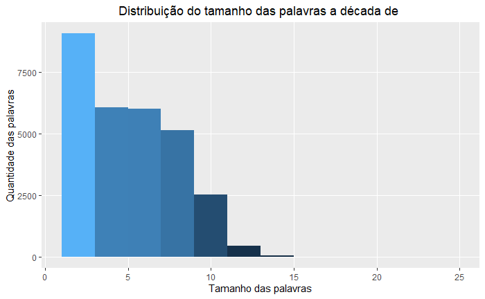

```r
PlotaTamanhosDasPalavras(ContaTamangoDasPalavrasPorDecada("2000s"), "2000s")
```

Nota: Preciso remover essas palavras o dataset

```r
wc <- all_word_lengths %>%
  ungroup() %>%
  select(word, word_length) %>%
  distinct() %>%
  arrange(desc(word_length))

wordcloud2(wc[1:300, ],
           size = .15,
           minSize = .0005,
           ellipticity = .3,
           rotateRatio = 1,
           fontWeight = "bold")
```

[output not shown]

# Densidade e Diversidade Lexical / Distribuição e Diversidade do vocabulário

Podemos observar o gráfico de distribuição das palavras no decorrer do tempo, para visualizar como as palavras exclusivas se distribuem no decorrer do tempo e avaliar a tendência das composições em relação repetição de palavras no decorrer do tempo.

Sabendo que a quantidade de letras passe por um crescimento acentuado no decorrer tempo, o gráfico indica um leve decaimento da densidade de palavras exclusivas no decorrer do tempo. Mesmo que seja uma avaliação subjetiva, podemos crer que, com o passar do tempo, mais as letras repetiram palavras e ficaram mais “pobres” em termos de seu vocabulário e também que as letras são mais repetitivas.

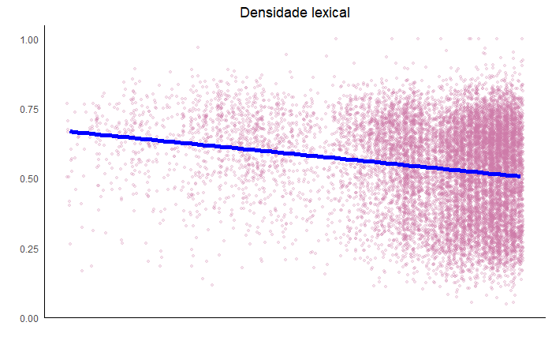

```r
densidade_lexical_por_ano <- musicas %>%
  filter(decada != "NA") %>%
  unnest_tokens(word, letra) %>%
  group_by(nome,ano) %>%
  summarise(lex_density = n_distinct(word)/n()) %>%
  arrange(desc(lex_density))

densidade_lexical_por_ano %>%
  ggplot(aes(ano, lex_density)) +
    geom_point(color = colors[4],
               alpha = .2,
               size = 1,
               position = "jitter") +
    stat_smooth(color = "black",
                se = FALSE,
                method = "lm") +
    geom_smooth(aes(x = ano, y = lex_density),
                se = FALSE,
                color = "blue",
                lwd = 2, method = 'gam') +
    ggtitle("Densidade lexical") +
    xlab("") +
    ylab("") +
    scale_color_manual(values = colors) +
    theme_classic() +
    theme_lyrics()
```

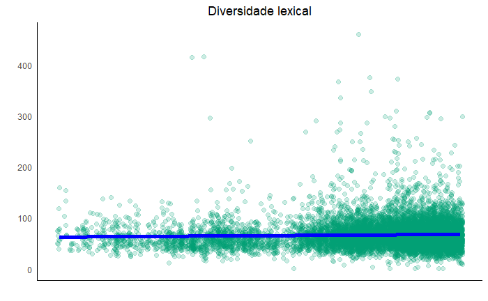

```r
diversidadelexical_por_ano <- musicas %>%
  filter(decada != "NA") %>%
  unnest_tokens(word, letra) %>%
  group_by(nome, ano) %>%
  summarise(lex_diversity = n_distinct(word)) %>%
  arrange(desc(lex_diversity))

diversidadelexical_por_ano %>%
  ggplot(aes(ano, lex_diversity)) +
    geom_point(color = colors[3],
               alpha = .2,
               size = 2,
               position = "jitter") +
    stat_smooth(color = "black", se = FALSE, method = "lm") +
    geom_smooth(aes(x = ano, y = lex_diversity), se = FALSE,
                color = "blue", lwd = 2, method = 'gam') +
    ggtitle("Diversidade lexical") +
    xlab("") +
    ylab("") +
    scale_color_manual(values = colors) +
    theme_classic() +
    theme_lyrics()
```

# Frequências / Popularidade de palavras

Visualização sobre a frequência com a qual as palavras mais aparecem por letra em relação com o número de letras que mais contém cada uma dessas palavras. Ou seja, a maior quantidade de palavras que aparecem em menos letras do conjunto de dados.

TF: Frequência de palavras mais repetidas por letra DF: Frequência de letras que contém cada palavra IDF: Frequência inversa por letra

A frequência é calculada por: TF - IFD = TF * IDF, onde FDI é a inversa de DF 1 / DF

As palavras mais comuns devem ter o seu IDF e TF * IDF com o valor zero.

```r
palavras_populares <- musicas %>%
  unnest_tokens(word, letra) %>%
  distinct() %>%
  filter(!word %in% palavras_indesejadas) %>%
  filter(nchar(word) > 3) %>%
  count(ano, word, sort = TRUE) %>%
  ungroup() %>%
  bind_tf_idf(word, ano, n)

head(palavras_populares)
```

| ano | word | n | tf | idf | tf_idf |
| --- | --- | --- | --- | --- | --- |
| 2015 | você | 637 | 0.01584301 | 0.01574836 | 0.0002495014 |
| 2016 | você | 601 | 0.01486998 | 0.01574836 | 0.0002341778 |
| 2017 | você | 583 | 0.01536515 | 0.01574836 | 0.0002419759 |
| 2018 | você | 560 | 0.01599452 | 0.01574836 | 0.0002518874 |
| 2015 | amor | 555 | 0.01380357 | 0.00000000 | 0.0000000000 |
| 2016 | amor | 530 | 0.01311329 | 0.00000000 | 0.0000000000 |

# Visualização enterior com gráficos

```
`show.legend` must be a logical vector.
```

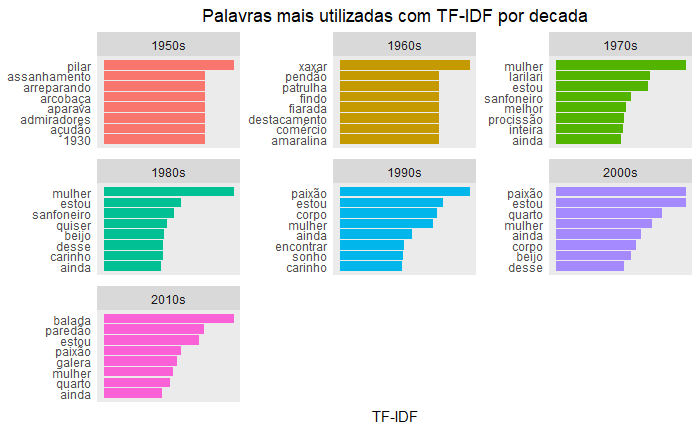

```r
tf_idf_palavras_decadas <- musicas %>%
  unnest_tokens(word, letra) %>%
  distinct() %>%
  filter(!word %in% palavras_indesejadas & decada != 'NA') %>%
  filter(nchar(word) > 3) %>%
  count(decada, word, sort = TRUE) %>%
  ungroup() %>%
  bind_tf_idf(word, decada, n) %>%
  arrange(desc(tf_idf))

top_tf_idf_palavras_decadas <- tf_idf_palavras_decadas %>%
  group_by(decada) %>%
  slice(seq_len(8)) %>%
  ungroup() %>%
  arrange(decada, tf_idf) %>%
  mutate(row = row_number())

top_tf_idf_palavras_decadas %>%
  ggplot(aes(x = row, tf_idf, fill = decada)) +
    geom_col(show.legend = NULL) +
    labs(x = NULL, y = "TF-IDF") +
    ggtitle("Palavras mais utilizadas com TF-IDF por decada") +
    theme_lyrics() +
    facet_wrap(~decada, ncol = 3, nrow = 3, scales = "free") +
    scale_x_continuous( breaks = top_tf_idf_palavras_decadas$row, labels = top_tf_idf_palavras_decadas$word) +
    coord_flip()
```

# Núvem de palavras por TF-IDF

```r
wc <- tf_idf_palavras_decadas %>%
  arrange(desc(tf_idf)) %>%
  select(word, tf_idf)

wordcloud2(wc[1:300, ],
           color = "random-dark",
           minSize = .005,
           ellipticity = .6,
           rotateRatio = 1,
           size = .1,
           fontWeight = "bold",
           gridSize = 2 )
```

[interactive chart not shown]